# Practical Machine Learning Project

Nikhilesh Jha

2/27/2018

# Executive Summary

In this project we fit different models to the dataset containing the way the Unilateral Dumbbell Curls was performed. While Class A refers to proper execution of the exercise, the rest correspond to improper execution. We use the features in the test data set to predict whether the person is executing the exercise properly or not. And if the person isn’t then what is he/she is doing wrong.

We split the data given to us into two subset of for training and cross validation, with 70% being allocated to the training set.

# Feature Selection

The data in the testing set has several columns with NAs. These columns will not contribute to the prediction hence we remove these columns as well while training models. The number of features is reduced from 160 to just 60. We remove the first columns named “X” as well. The columns serves as a Unique identifier and is not got for extrapolating the model.

# Different Models

We use three different type of models - Recursive Partitioning, Linear Discriminant Analysis and Random Forest. The Recursive Partioning decision tree and LDA both have 5 fold partition on the training set provided to them.

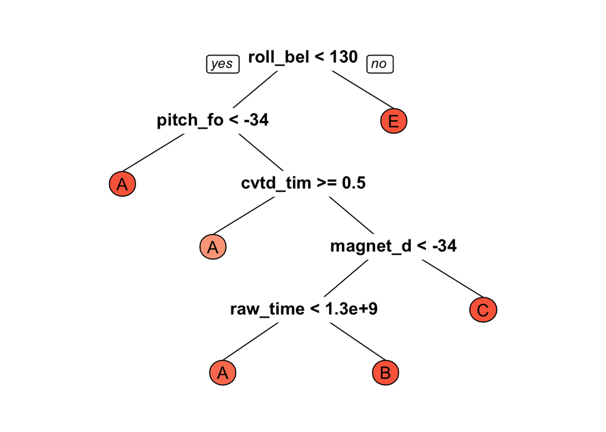

The Accuracy on the in sample (training) data from the recursive tree is 46.58% and on the out of sample (cross validation) set it 46.15%. While this is better than just guessing which would be able to predict accurately 1/5 or 20% times, the predictability is pretty low compared to other models.

The Accuracy on the in sample data from Linear Discriminant Analysis is 85.2% and on the cross validation data it 85.68%.

The Random Forest model has an accuracy of 100% on the in sample data and 99.98% accuracy on cross validation data.

The out of sample error is slightly higher, which is to be expected in these models. We will be using the Random Forest and LDA model for prediction on test set due to higher accuracy.